# Exercise_03_BC

Betsy Cowdery

September 22, 2014

# Case study 1: Survival Analysis

#### Include code to make a plot of the exponential PDF (with the MLE parameter estimate) on top of the histogram of the data.

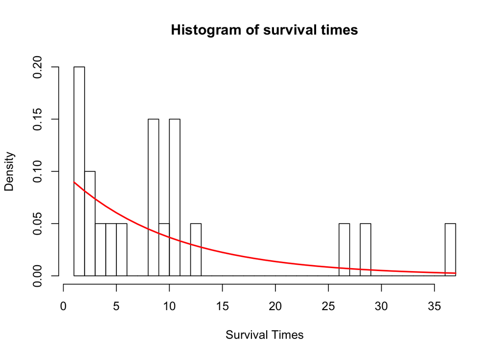

```r
dat <- c(1,9,9,5,27,9,29,1,11,3,3,11,13,6,11,2,4,1,37,10)
n <- length(dat)

elik <- function(rho){
  -n*log(rho) + rho*sum(dat)
}

fit_exp <- optimize(elik,lower=0.01,upper=0.9,maximum=F)
rho_mle <- fit_exp$minimum
rho_case1 <- rho_mle

x <- 1:37
hist(dat,freq=FALSE,nclass = max(dat), xlab="Survival Times", main="Histogram of survival times")
lines(x,dexp(x,rate=rho_mle), col=2, lwd=2)
```

# Case Study 2: Change in Fire Risk With Time

Fire return interval are frequently analyzed using a Weibull distribution:

$f(x \vert c, \lambda) = \left({{c}\over{\lambda}}\right)\left( {x \over \lambda} \right)^{c-1} exp\left( -\left( {x\over \lambda} \right)^c \right)$

#### Does increasing the “shape” parameter cause fire risk to increase or decrease with age?

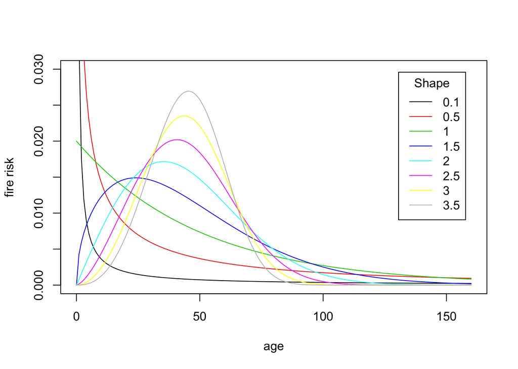

As the “shape” variable increases, we can see the shape of the PDF change switch from a curve resembling an exponential distribution to one that looks more and more normal around the value 50 (the “scale” value). With this shift, we can see that the greatest change of risk is moving further away from zero. Depending on the size of the tail of the curve, there may be a non-zero risk up to and past 150 years, but as the distriibution settles around 50, it narrows and the risk of fire in very late years (100+) decreases again.

#### Plot the CDF of these 3 distributions. What is significant about the scale parameter? What is the analytical solution for the CDF at this point? Add these lines to your CDF plot.

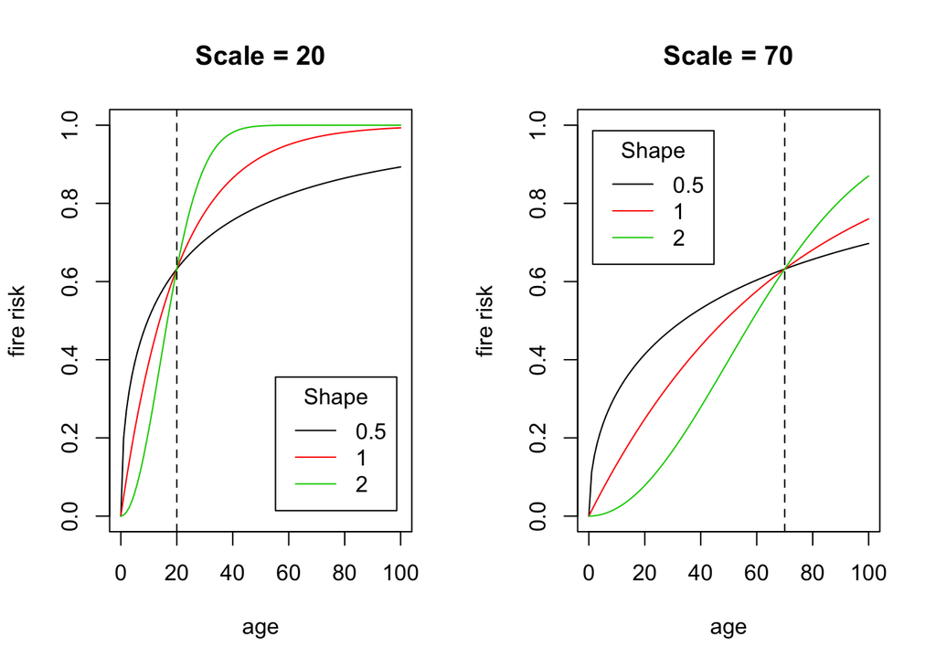

### Fire Data

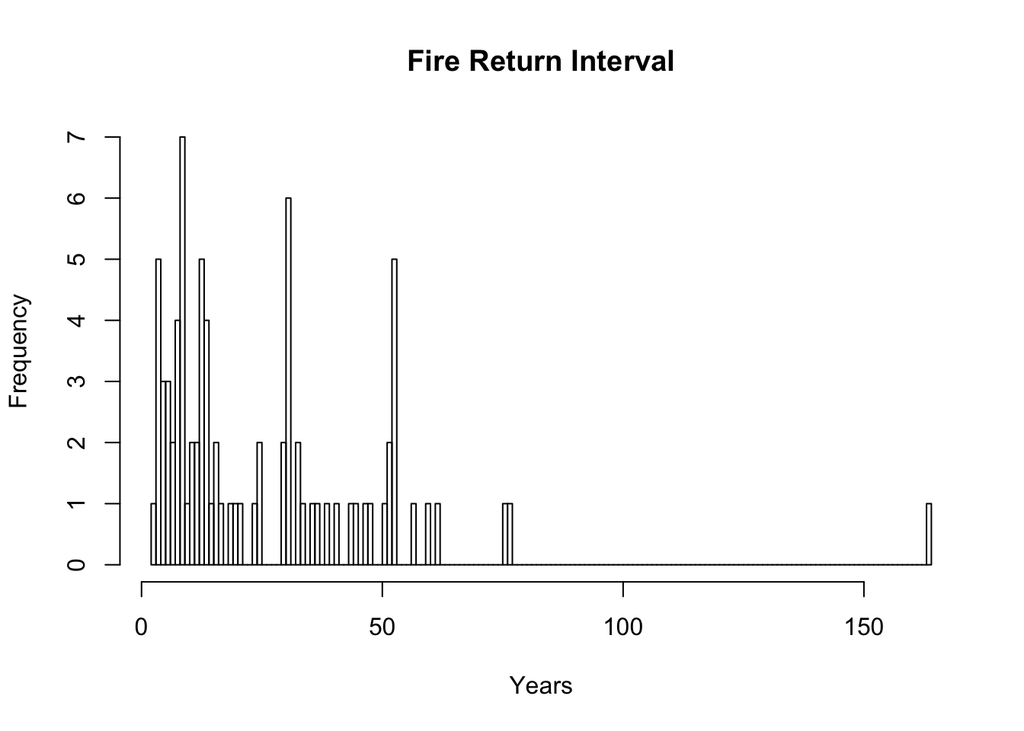

```
##    Min. 1st Qu.  Median    Mean 3rd Qu.    Max.
##     2.0     9.0    16.0    26.1    36.8   164.0
```

#### Since the exponential is a special case of the Weibull, use the code from the first case study to solve for the exponential MLE (rho_mle) for the fire scar data

Negative log likelihood function for the Exponential model:

```r
elik <- function(rho){
  -n*log(rho) + rho*sum(dat)
}
```

Optimize to get rho_mle:

```r
dat <- firedata
n <- length(dat)

fit_exp <- optimize(elik,lower=0.01,upper=0.9,maximum=F)
rho_mle <- fit_exp$minimum
fit_exp
```

```
## $minimum
## [1] 0.03835
##
## $objective
## [1] 349.4
```

Negative log likelihood function for the Weibull model:

```r
wlik <- function(param){
 -sum(dweibull(dat, param[1], param[2], log = TRUE))
}
```

Optimize to get “shape” and “scale”:

```r
param0 <- c(1.0,1/rho_mle)
dat <- firedata
out <- optim(param0,wlik,lower=c(0.01,0.01), upper=c(100,100),method="L-BFGS-B")
out
```

```
## $par
## [1]  1.189 27.801
##
## $value
## [1] 347.4
##
## $counts
## function gradient
##       18       18
##
## $convergence
## [1] 0
##
## $message
## [1] "CONVERGENCE: REL_REDUCTION_OF_F <= FACTR*EPSMCH"
```

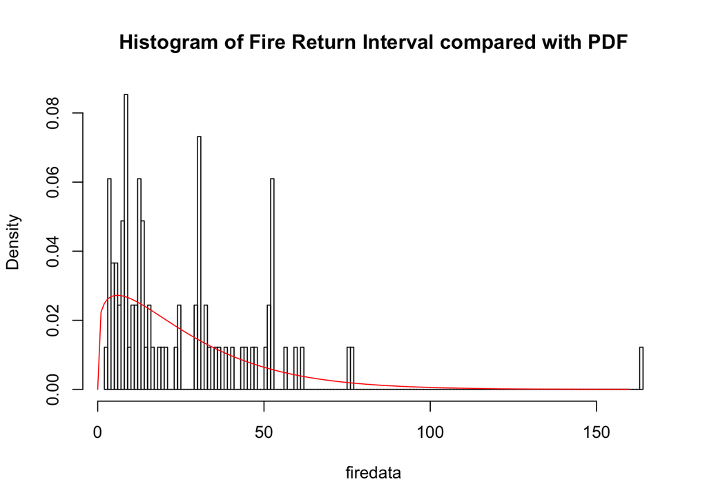

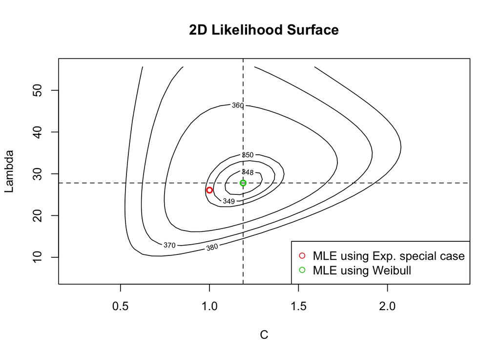

## Case study 3: Binomial/Exponential Mortality

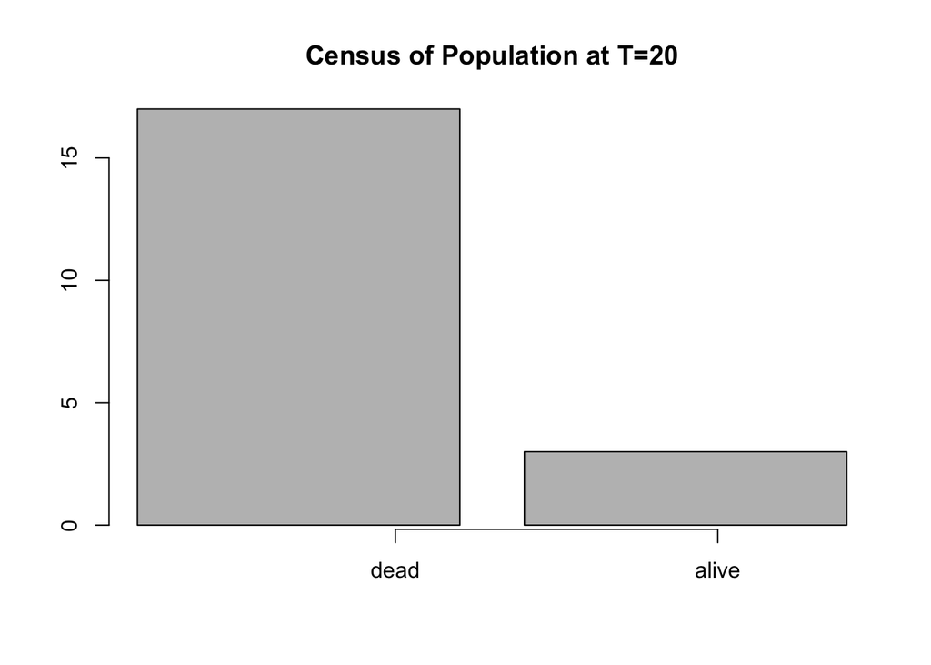

$L = Binom(y \vert N, \theta) \propto \theta^y \left( 1-\theta \right)^{N-y}$

$\theta_{ML}=\frac{y}{N}$

$L = Binom(y \vert N, \rho) \propto e^{-\rho T y} \left( 1-e^{-\rho T} \right)^{N-y}$

$\rho_{ML}=\frac{-\ln{y/N}}{T}$

#### Apply one of the **numerical methods** you used above in order to estimate $\rho$.

Include the following in your answer:

- R code
- Numerical estimate of rho
- Negative log likelihood profile

First, calculate analytical solutions:

```r
theta_ml <- y/n
rho_ml <- -log(y/n)/t
```

Likelihood function:

```r
binexp <- function(rho){
  exp(-rho*t*y)*(1-exp(-rho*t))^(n-y)
  }
```

Negative Log Likelihood functions:

```r
# Binomial
lbin <- function(theta){
  -dbinom(y,n,theta,log=T)
}

# Combined Binomial and Exponential
lbinexp <- function(rho){
  rho*t*y - (n-y)*log(1-exp(-rho*t))
}
```

```r
rseq <- seq(.01,.99,.01)

fit <- optimize(lbin,lower=.01, upper=.99,maximum=F)
theta_ml_o <- fit$minimum
theta_ml
```

```
## [1] 0.15
```

```r
theta_ml_o
```

```
## [1] 0.15
```

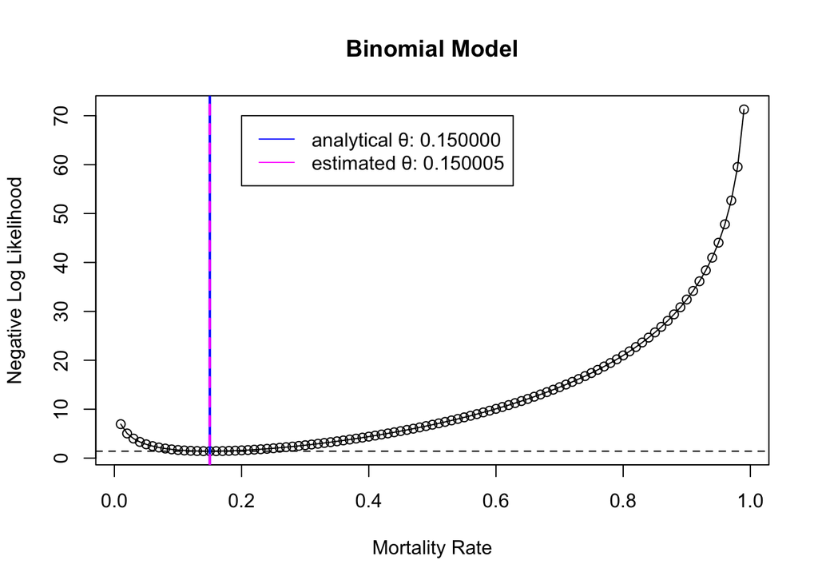

```r
rseq <- seq(.01,.99,.01)
plot(rseq,lbin(rseq),ylab ="Negative Log Likelihood",xlab="Mortality Rate",main="Binomial Model")
lines(rseq,lbin(rseq))
abline(v=theta_ml, lwd=2, col=4)
abline(v=theta_ml_o,lty=2,lwd=2, col=6)
abline(h=lbin(theta_ml_o),lty=2)
legend(.2,70, legend = c(sprintf("analytical %s: %.6f","θ",theta_ml), sprintf("estimated %s: %.6f","θ",theta_ml_o)) , lty = 1, col = c(4,6),bg="white")
```

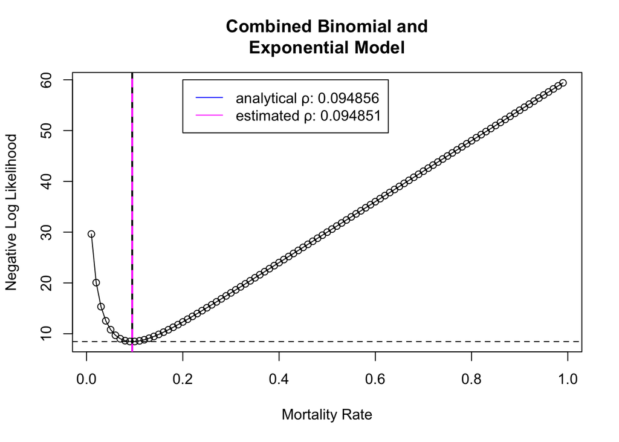

```r
fit <- optimize(lbinexp,lower=.01, upper=.99,maximum=F)
rho_ml_o <- fit$minimum
rseq <- seq(.01,.99,.01)
plot(rseq,lbinexp(rseq),ylab ="Negative Log Likelihood",xlab="Mortality Rate")
title("Combined Binomial and
Exponential Model")
lines(rseq,lbinexp(rseq))
abline(v=rho_ml, lwd=2)
abline(v=rho_ml_o,lty=2,lwd=2, col=6)
abline(h=lbinexp(rho_ml_o),lty=2)
legend(.2,60, legend = c(sprintf("analytical %s: %.6f","ρ",rho_ml), sprintf("estimated %s: %.6f","ρ",rho_ml_o)) , lty = 1, col = c(4,6),bg="white")
```

#### If we wanted to test the assumption that mortality rate was constant in time, which of the two data sets could we use and what model would we fit?

We would need to use the data set from the first example that has many measurements through time. With this data set, we can try fitting a Weibull distribution, the only distribution so far that does not assume $\rho$ to be constant.

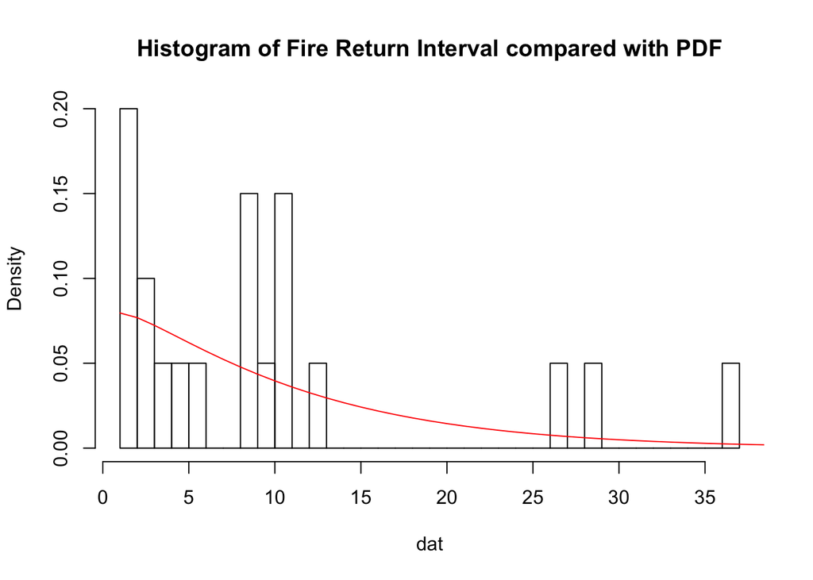

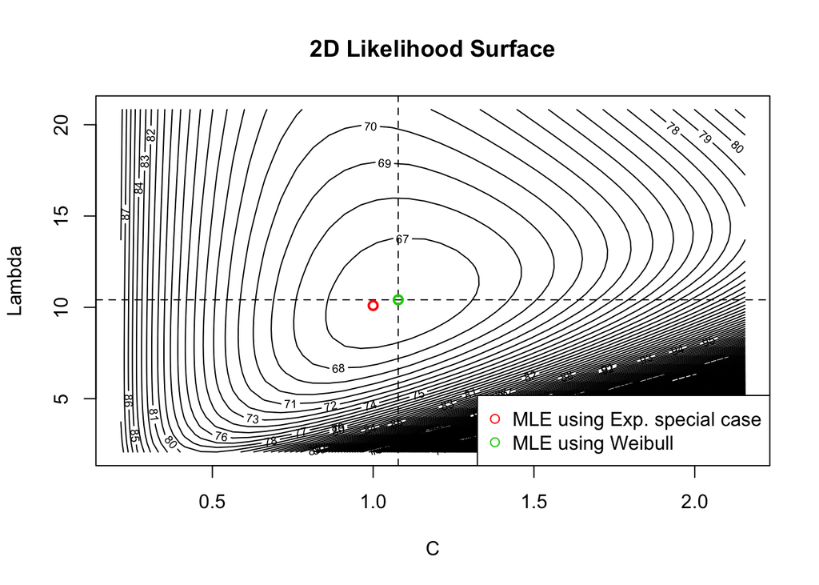

#### Extra Credit: A plot of the exponential PDF with two curves, one based on the Exponential model from the start of this lab and the second from the Binomial/Exponential fit you just found

```r
dat <- c(1,9,9,5,27,9,29,1,11,3,3,11,13,6,11,2,4,1,37,10)
t <- 1:max(dat)

rho_case1
```

```
## [1] 0.09901
```

```r
rho_case3
```

```
## [1] 0.09485
```

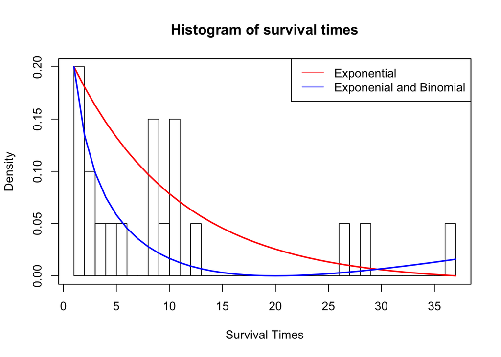

```r
hist(dat,freq=FALSE,nclass = max(dat), xlab="Survival Times", main="Histogram of survival times")
par(new=TRUE)
plot(t,dexp(t,rate=rho_case1), col="red",type="l",lwd=2,xaxt = "n",yaxt = "n",ylab = "",xlab="")
par(new=TRUE)
plot(t,lbinexp(rho_case3), col="blue",type="l",lwd=2,xaxt = "n",yaxt = "n", ylab="",xlab="")
legend("topright",col=c("red","blue"),lty=1,legend=c("Exponential","Exponenial and Binomial"))
```